# R 중급 통계분석 4일차 (1)

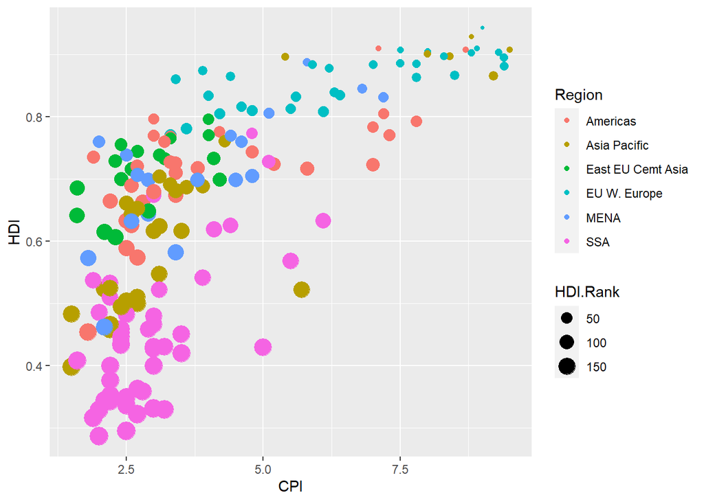

```r
ggplot(dat, aes(x = CPI, y = HDI)) +
geom_point(aes(color = Region, size =  HDI.Rank))
```

6. 산점도 위에 smooth 선을 그리세요.

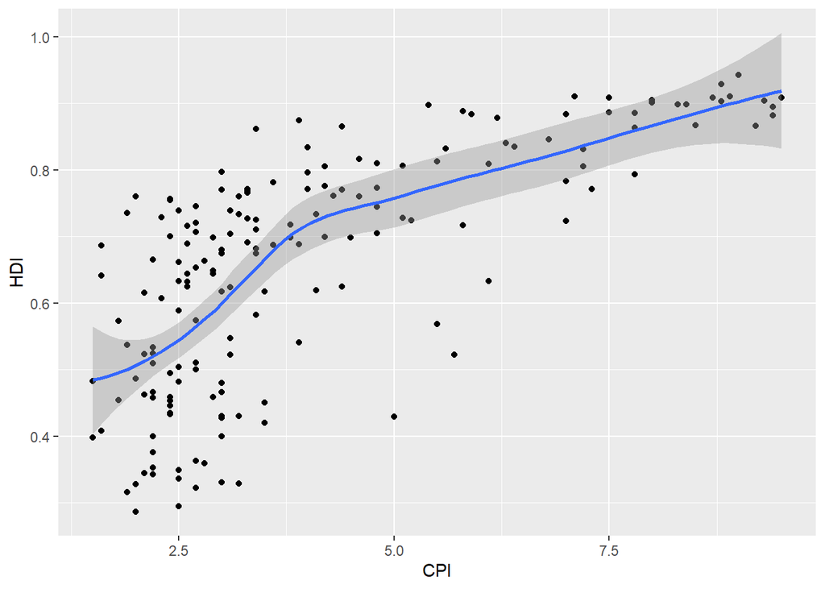

```r
ggplot(dat, aes(x = CPI, y = HDI)) +
  geom_point() +
  geom_smooth()
```

7. smooth 선이 직선으로 그리세요.

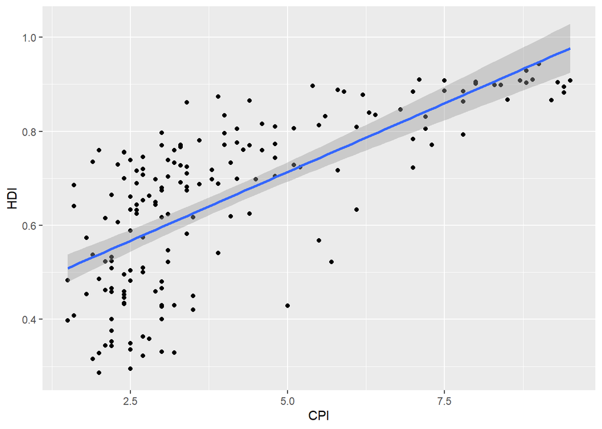

```r
ggplot(dat, aes(x = CPI, y = HDI)) +
  geom_point() +
  geom_smooth(method = "lm")
```

8. 신뢰구간이 표현되지 않도록 수정하세요.

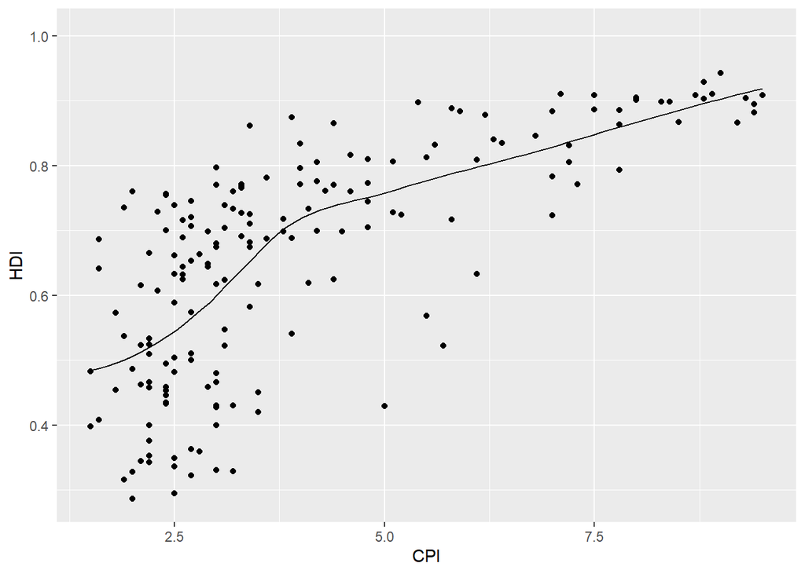

```r
ggplot(dat, aes(x = CPI, y = HDI)) +
  geom_point() +
  geom_line(stat = "smooth", method = "loess")
```

9. 축과 범례의 이름을 변경하세요.

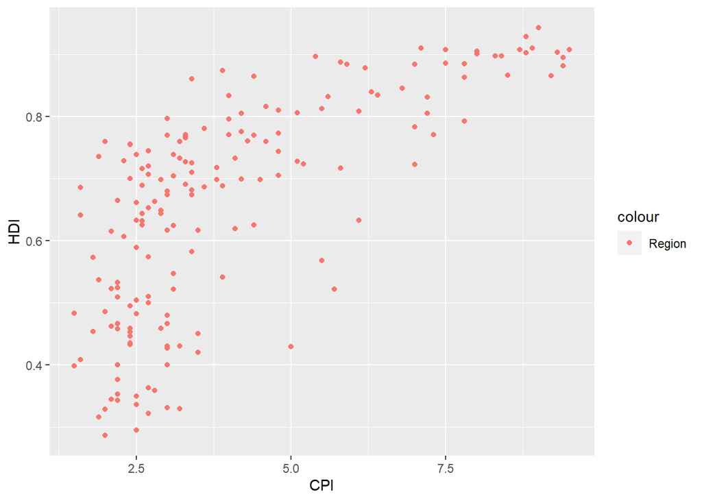

```r
ggplot(dat, aes(x = CPI, y = HDI, color = "Region")) +
  geom_point()
```

위 그림에서 X축과 Y축 그리고 범례를 수정하세요.

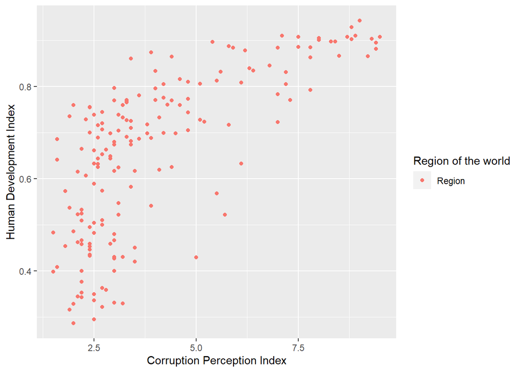

```r
ggplot(dat, aes(x = CPI, y = HDI, color = "Region")) +
geom_point() +
scale_x_continuous(name = "Corruption Perception Index") +
scale_y_continuous(name = "Human Development Index") +
scale_color_discrete(name = "Region of the world")
```

10. aes(color)에 state를 이용하면,

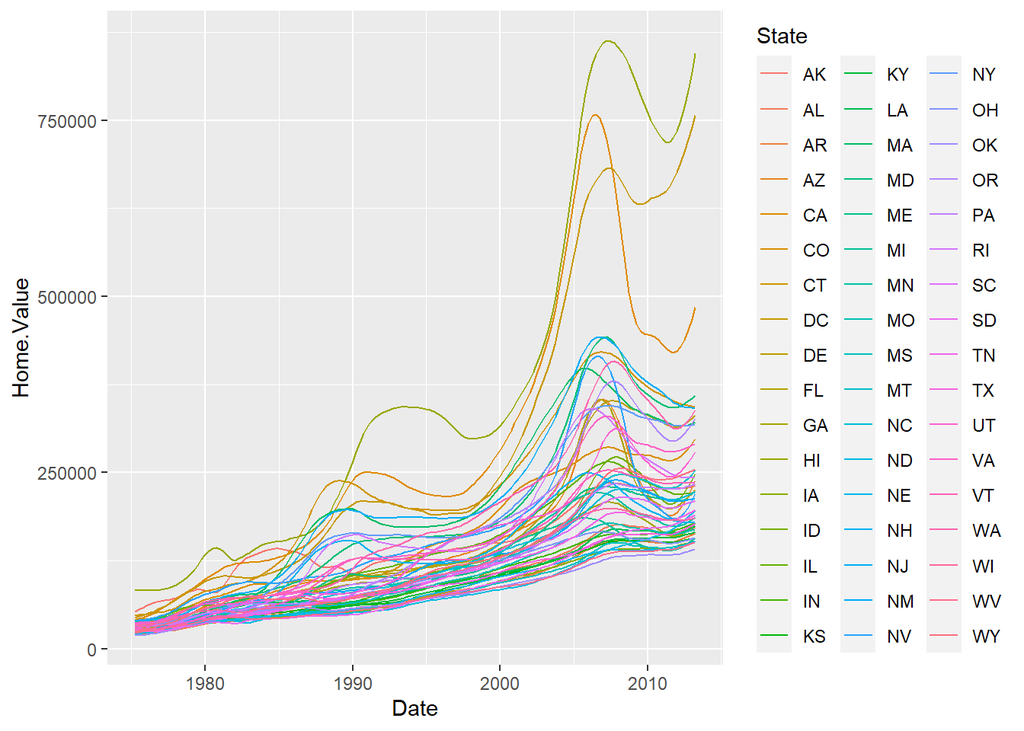

```r
p5 <- ggplot(housing, aes(x = Date, y = Home.Value))
p5 + geom_line(aes(color = State))
```

를 그릴 수 있다. facter_wrap을 이용하여 아래의 그림을 그리세요.

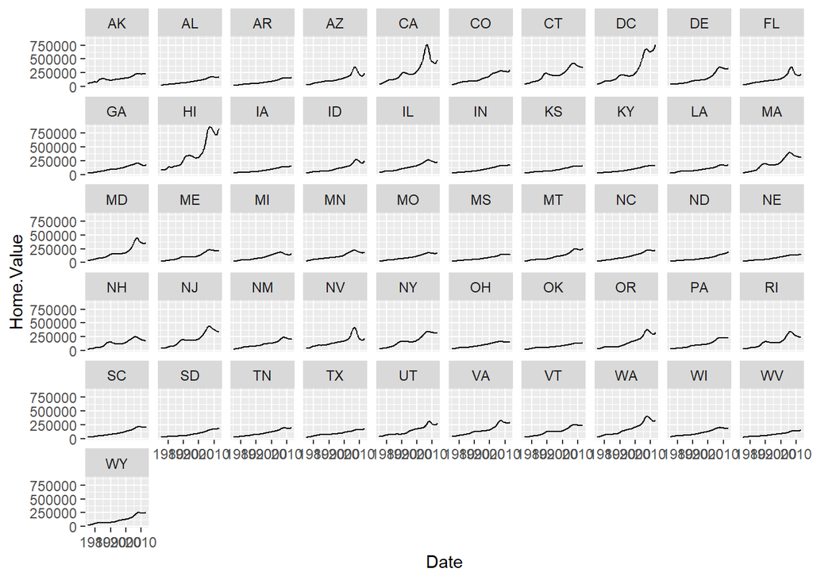

```r
(p5 <- p5 + geom_line() +
   facet_wrap(~State, ncol = 10))
```

추가로 위의 그림의 마지막에 theme_linedraw()를 사용하면

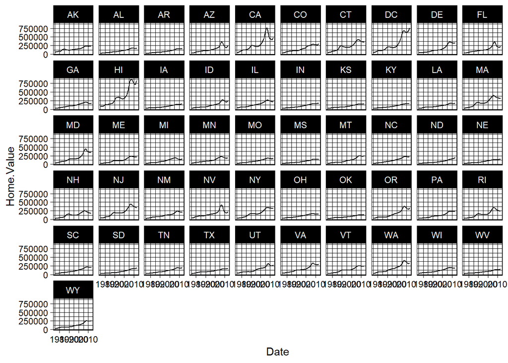

```r
p5 + theme_linedraw()
```

가 그려진다.

11. 아래의 코드는 scale 참고용 코드입니다.

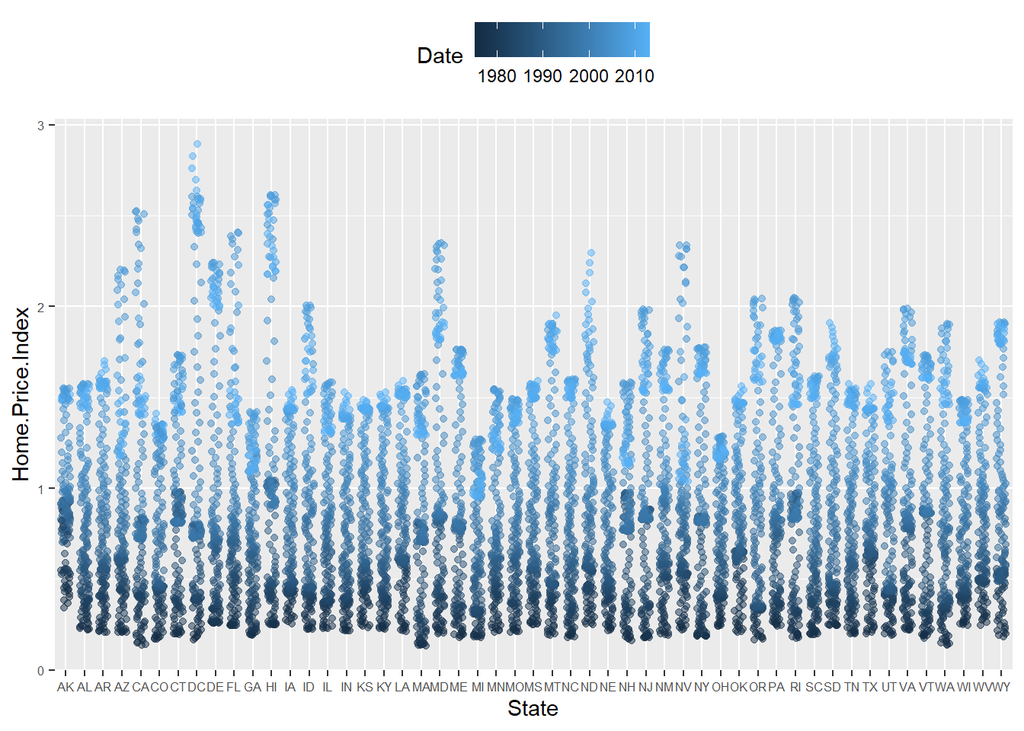

```r
p3 <- ggplot(housing,
             aes(x = State,
                 y = Home.Price.Index)) +
        theme(legend.position="top",
              axis.text=element_text(size = 6))
p4 <- p3 + geom_point(aes(color = Date),
                       alpha = 0.5,
                       size = 1.5,
                       position = position_jitter(width = 0.25, height = 0))
p4
```

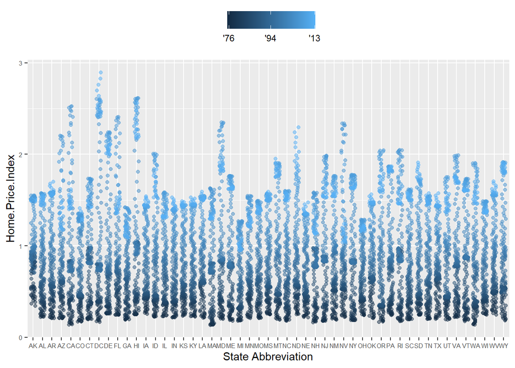

```r
p4 + scale_x_discrete(name="State Abbreviation") +
  scale_color_continuous(name="",
                         breaks = c(1976, 1994, 2013),
                         labels = c("'76", "'94", "'13"))
```

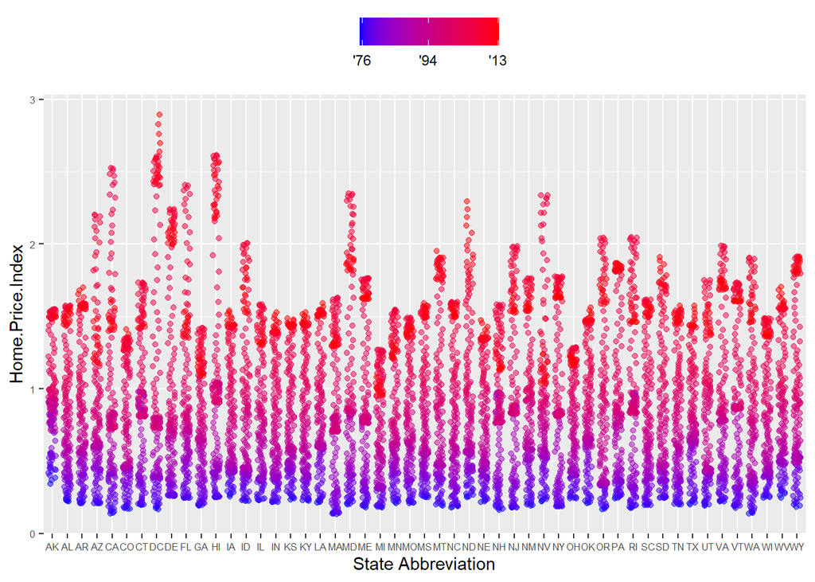

```r
p4 +
  scale_x_discrete(name="State Abbreviation") +
  scale_color_continuous(name="",
                         breaks = c(1976, 1994, 2013),
                         labels = c("'76", "'94", "'13"),
                         low = "blue", high = "red")
```